# Transmission System vs Fuel Efficiency

Simin Talebpour

### Executive Summary

In this project I want to analyze **mtcars** dataset(a collection of cars), to explore the relationship between a set of variables and miles per gallon (MPG). I’m particularly interested in the following two questions:  
-Is an automatic or manual transmission better for MPG?  
-Quantify the MPG difference between automatic and manual transmissions?

### Exploratory Data Analyses

```
## 'data.frame':    32 obs. of  11 variables:
##  $ mpg : num  21 21 22.8 21.4 18.7 18.1 14.3 24.4 22.8 19.2 ...
##  $ cyl : num  6 6 4 6 8 6 8 4 4 6 ...
##  $ disp: num  160 160 108 258 360 ...
##  $ hp  : num  110 110 93 110 175 105 245 62 95 123 ...
##  $ drat: num  3.9 3.9 3.85 3.08 3.15 2.76 3.21 3.69 3.92 3.92 ...
##  $ wt  : num  2.62 2.88 2.32 3.21 3.44 ...
##  $ qsec: num  16.5 17 18.6 19.4 17 ...
##  $ vs  : num  0 0 1 1 0 1 0 1 1 1 ...
##  $ am  : num  1 1 1 0 0 0 0 0 0 0 ...
##  $ gear: num  4 4 4 3 3 3 3 4 4 4 ...
##  $ carb: num  4 4 1 1 2 1 4 2 2 4 ...
```

The mtcars dataset consists of 32 observations of 11 (numeric) variables.  
Looking at the box plot(Fig-1), I can say that manual cars are more gas efficient. I can verify that with a hypothesis test of simple linear regression.

### Inference in Regression

I want to know if there is significant evidence that ‘mph’ depends on transmission system(‘am’ variable)? Applying a simple regression, answers this question. Regression conducts a hypothesis test on the slope of the regression line using t-test methods to test the following hypothesis:  
- Is the slope(coefficient for ‘am’) significantly different from zero?

```r
fit <- lm(mpg ~ factor(am), data = mtcars)
summary(fit)$coef
```

```
##              Estimate Std. Error   t value     Pr(>|t|)
## (Intercept) 17.147368   1.124603 15.247492 1.133983e-15
## factor(am)1  7.244939   1.764422  4.106127 2.850207e-04
```

The P-value of 2.850207e-04 is significant(smaller than 0.05), so I reject the null hypothesis meaning that slope in my regression model is not zero, therefore it’s statistically significant, so the result shows that the transmission system effects fuel consumption.

### Model Selection

I want to find a model that includes all the important variables to predict the outcome. First I fit a model that includes all the variables.

```r
fit_all <- lm(mpg ~ cyl+disp+hp+drat+wt+qsec+factor(vs)+factor(am)+gear+carb, data = mtcars)
```

Looking at the results in Table_1, I find none of the variables statistically significant(all p-vales are geater than 0.05). I need the best selection of variables. setp() function does it by implementing Stepwise regression.

```r
library(MASS)
step <- step(fit_all, direction="both", trace=FALSE)
summary(step)$coeff
```

```
##              Estimate Std. Error   t value     Pr(>|t|)
## (Intercept)  9.617781  6.9595930  1.381946 1.779152e-01
## wt          -3.916504  0.7112016 -5.506882 6.952711e-06
## qsec         1.225886  0.2886696  4.246676 2.161737e-04
## factor(am)1  2.935837  1.4109045  2.080819 4.671551e-02
```

```r
sprintf('Adjusted R-squared: %f', summary(step)$adj.r.squared)
```

```
## [1] "Adjusted R-squared: 0.833556"
```

according to this result, the best fit is:  
Bestfit <- lm(mpg ~ wt+qsec+factor(am), data = mtcars)

The best model says that fuel consumption in cars mostly depends on the car’s weight(wt), quarter mile time(qsec) and transmission system(am), and. The adjusted R-squared is 83% which means that the model explains 83% of the variation in mpg, indicating it is a robust model.  
Based on the best model results, the mean of ‘mpg’ for cars with manual transmission system is 2.94 more than automatic transmission cars. We found a differnt value in this model from the simple linear regression model(which was 7.24), and that’s because I adjusted first fit with other varialbes(wt, qsec).

### Conclusion

Based on my Analysis, I can say that in terms of fuel efficiency, a manual transmission is a better option than automatic. Holding all other variables constant, on average, ‘mph’ in manual cars is 2.94 more than automatic cars. The best model I found explains 83% of the variability in the response variable(mpg).

### Appendix

#### Fig_1

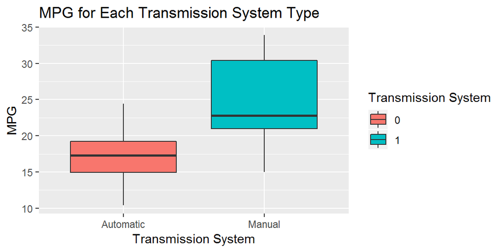

#### Table_1

```r
summary(fit_all)$coeff
```

```
##                Estimate  Std. Error    t value   Pr(>|t|)
## (Intercept) 12.30337416 18.71788443  0.6573058 0.51812440
## cyl         -0.11144048  1.04502336 -0.1066392 0.91608738
## disp         0.01333524  0.01785750  0.7467585 0.46348865
## hp          -0.02148212  0.02176858 -0.9868407 0.33495531
## drat         0.78711097  1.63537307  0.4813036 0.63527790
## wt          -3.71530393  1.89441430 -1.9611887 0.06325215
## qsec         0.82104075  0.73084480  1.1234133 0.27394127
## factor(vs)1  0.31776281  2.10450861  0.1509915 0.88142347
## factor(am)1  2.52022689  2.05665055  1.2254035 0.23398971
## gear         0.65541302  1.49325996  0.4389142 0.66520643
## carb        -0.19941925  0.82875250 -0.2406258 0.81217871
```

#### Stepwise Regression

The general idea behind the stepwise regression procedure is that we build our regression model from a set of candidate predictor variables by entering and removing predictors - in a stepwise manner - into our model until there is no justifiable reason to enter or remove any more.

Refrence: https://newonlinecourses.science.psu.edu/stat501/node/329/

#### Fig-2

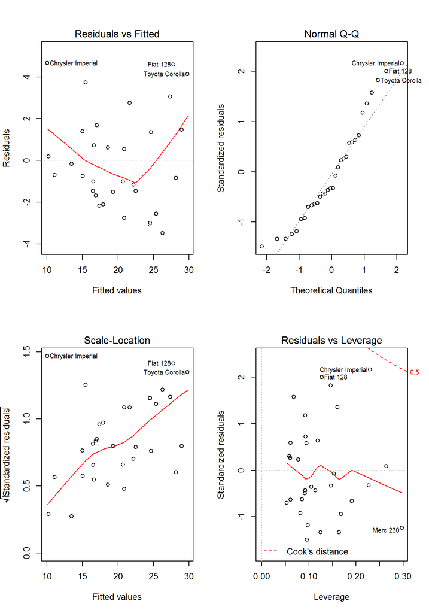

```r
Bestfit <- lm(mpg ~ wt+qsec+factor(am), data = mtcars)
par(mfrow = c(2,2))
plot(Bestfit)
```